# csc5610ProjectM1

csc5610 Project M1 Chris Troop

```python
import pandas as pd
import numpy as np

carPrice_df = pd.read_csv('UsedCarSalePrices.csv')

carPrice_df.head()
```

|  | Id | Model | Price | Age_08_04 | KM | Fuel_Type | HP | Color | Automatic | CC | ... | Power_Steering | Radio | Mistlamps | Sport_Model | Backseat_Divider | Metallic_Rim | Radio_cassette | Parking_Assistant | Tow_Bar | Mfg_Date |
| --- | --- | --- | --- | --- | --- | --- | --- | --- | --- | --- | --- | --- | --- | --- | --- | --- | --- | --- | --- | --- | --- |
| 0 | 1 | TOYOTA Corolla 2.0 D4D HATCHB TERRA 2/3-Doors | 13500 | 23 | 46986 | Diesel | 90 | Blue (Metallic) | No | 2000 | ... | Yes | No | No | No | Yes | No | No | No | No | 10/1/02 |
| 1 | 2 | TOYOTA Corolla 2.0 D4D HATCHB TERRA 2/3-Doors | 13750 | 23 | 72937 | Diesel | 90 | Silver (Metallic) | No | 2000 | ... | Yes | No | No | No | Yes | No | No | No | No | 10/1/02 |
| 2 | 3 | TOYOTA Corolla 2.0 D4D HATCHB TERRA 2/3-Doors | 13950 | 24 | 41711 | Diesel | 90 | Blue (Metallic) | No | 2000 | ... | Yes | No | No | No | Yes | No | No | No | No | 9/1/02 |
| 3 | 4 | TOYOTA Corolla 2.0 D4D HATCHB TERRA 2/3-Doors | 14950 | 26 | 48000 | Diesel | 90 | Black | No | 2000 | ... | Yes | No | No | No | Yes | No | No | No | No | 7/1/02 |
| 4 | 5 | TOYOTA Corolla 2.0 D4D HATCHB SOL 2/3-Doors | 13750 | 30 | 38500 | Diesel | 90 | Black | No | 2000 | ... | Yes | No | Yes | No | Yes | No | No | No | No | 3/1/02 |

5 rows × 37 columns

```python
carPrice_df.tail()
```

|  | Id | Model | Price | Age_08_04 | KM | Fuel_Type | HP | Color | Automatic | CC | ... | Power_Steering | Radio | Mistlamps | Sport_Model | Backseat_Divider | Metallic_Rim | Radio_cassette | Parking_Assistant | Tow_Bar | Mfg_Date |
| --- | --- | --- | --- | --- | --- | --- | --- | --- | --- | --- | --- | --- | --- | --- | --- | --- | --- | --- | --- | --- | --- |
| 1431 | 1438 | TOYOTA Corolla 1.3 16V HATCHB G6 2/3-Doors | 7500 | 69 | 20544 | Petrol | 86 | Blue (Metallic) | No | 1300 | ... | Yes | No | Yes | Yes | Yes | No | No | No | No | 12/1/98 |
| 1432 | 1439 | TOYOTA Corolla 1.3 16V HATCHB LINEA TERRA 2/3-... | 10845 | 72 | 19000 | Petrol | 86 | Grey | No | 1300 | ... | Yes | No | No | Yes | Yes | No | No | No | No | 9/1/98 |
| 1433 | 1440 | TOYOTA Corolla 1.3 16V HATCHB LINEA TERRA 2/3-... | 8500 | 71 | 17016 | Petrol | 86 | Blue | No | 1300 | ... | Yes | No | No | No | Yes | No | No | No | No | 10/1/98 |
| 1434 | 1441 | TOYOTA Corolla 1.3 16V HATCHB LINEA TERRA 2/3-... | 7250 | 70 | 16916 | Petrol | 86 | Grey (Metallic) | No | 1300 | ... | No | No | No | No | Yes | No | No | No | No | 11/1/98 |
| 1435 | 1442 | TOYOTA Corolla 1.6 LB LINEA TERRA 4/5-Doors | 6950 | 76 | 1 | Petrol | 110 | Green | No | 1600 | ... | Yes | No | No | No | No | No | No | No | No | 5/1/98 |

5 rows × 37 columns

```python
carPrice_df.info()
```

```
<class 'pandas.core.frame.DataFrame'>
RangeIndex: 1436 entries, 0 to 1435
Data columns (total 37 columns):
 #   Column             Non-Null Count  Dtype
---  ------             --------------  -----
 0   Id                 1436 non-null   int64
 1   Model              1436 non-null   object
 2   Price              1436 non-null   int64
 3   Age_08_04          1436 non-null   int64
 4   KM                 1436 non-null   int64
 5   Fuel_Type          1436 non-null   object
 6   HP                 1436 non-null   int64
 7   Color              1436 non-null   object
 8   Automatic          1436 non-null   object
 9   CC                 1436 non-null   int64
```

[output cut: 29 more lines]

```python
carPrice_df.describe()
```

|  | Id | Price | Age_08_04 | KM | HP | CC | Doors | Cylinders | Gears | Quarterly_Tax | Weight | Guarantee_Period |
| --- | --- | --- | --- | --- | --- | --- | --- | --- | --- | --- | --- | --- |
| count | 1436.000000 | 1436.000000 | 1436.000000 | 1436.000000 | 1436.000000 | 1436.00000 | 1436.000000 | 1436.000000 | 1436.000000 | 1436.000000 | 1436.00000 | 1436.000000 |
| mean | 721.555014 | 10681.468663 | 55.947075 | 68533.259749 | 101.502089 | 1576.85585 | 4.033426 | 3.770195 | 5.026462 | 86.838440 | 1072.45961 | 3.815460 |
| std | 416.476890 | 3621.377346 | 18.599988 | 37506.448872 | 14.981080 | 424.38677 | 0.952677 | 1.047367 | 0.188510 | 41.297734 | 52.64112 | 3.011025 |
| min | 1.000000 | 1625.000000 | 1.000000 | 1.000000 | 69.000000 | 1300.00000 | 2.000000 | -1.000000 | 3.000000 | 0.000000 | 1000.00000 | 3.000000 |
| 25% | 361.750000 | 8450.000000 | 44.000000 | 43000.000000 | 90.000000 | 1400.00000 | 3.000000 | 4.000000 | 5.000000 | 69.000000 | 1040.00000 | 3.000000 |
| 50% | 721.500000 | 9900.000000 | 61.000000 | 63389.500000 | 110.000000 | 1600.00000 | 4.000000 | 4.000000 | 5.000000 | 85.000000 | 1070.00000 | 3.000000 |
| 75% | 1081.250000 | 11935.000000 | 70.000000 | 87020.750000 | 110.000000 | 1600.00000 | 5.000000 | 4.000000 | 5.000000 | 85.000000 | 1085.00000 | 3.000000 |
| max | 1442.000000 | 32500.000000 | 80.000000 | 243000.000000 | 192.000000 | 16000.00000 | 5.000000 | 4.000000 | 6.000000 | 283.000000 | 1615.00000 | 36.000000 |

Infering Variable types and marking complex for later spliting

- Id - int64
- Model - Complex ("MAKE" "Model" "Engine" "Body Type" "Doors")
- Price - float64
- Age_08_03 - int64
- KM -int64
- Fuel_Type - Category
- HP - int64
- Color - category
- Automatic - category
- CC - int64
- Doors - category
- Cylinders - category
- Gears - category
- Quarterly_Tax - float64
- Weight - int64
- Mfr_Guarantee - category
- BOVAG_Guarantee - category
- Guarantee_Period - category
- ABS - category
- Airbag_1 - category
- Airbag_2 - category
- Airco - category
- Automatic_airco- category
- Boardcomputer- category
- CD_Player- category
- Central_Lock- category
- Powered_Windows- category
- Power_Steering- category
- Radio- category
- Mistlamps- category
- Sport_Model- category
- Backseat_Divider - category
- Metallic_Rim - category
- Radio_cassette - category
- Parking_Assistant- category
- Tow_Bar - category
- Mfg_Date - datetime64

```python
print(len(set(carPrice_df["Quarterly_Tax"])))
print(set(carPrice_df["Quarterly_Tax"]))
```

[output not shown]

```python
carPrice_df.astype({'Id':'int32', 'Price':'float64', 'Fuel_Type': 'category', 'Color':'category', 'Automatic':'category', 'Doors':'category', 'Cylinders':'category', 'Gears':'category', 'Quarterly_Tax':'float64', 'Mfr_Guarantee':'category', 'BOVAG_Guarantee':'category', 'Guarantee_Period':'category', 'ABS':'category', 'Airbag_1':'category',  'Airbag_2':'category', 'Airco':'category', 'Automatic_airco' : 'category' ,'Boardcomputer':'category', 'CD_Player':'category', 'Central_Lock':'category', 'Powered_Windows':'category', 'Power_Steering':'category', 'Radio':'category',  'Mistlamps':'category', 'Sport_Model':'category',  'Backseat_Divider':'category', 'Metallic_Rim':'category', 'Radio_cassette':'category', 'Parking_Assistant':'category',  'Tow_Bar':'category', 'Mfg_Date':'datetime64[ns]'}).dtypes
```

```
Id                            int32
Model                        object
Price                       float64
Age_08_04                     int64
KM                            int64
Fuel_Type                  category
HP                            int64
Color                      category
Automatic                  category
CC                            int64
Doors                      category
Cylinders                  category
Gears                      category
Quarterly_Tax               float64
Weight                        int64
Mfr_Guarantee              category
BOVAG_Guarantee            category
Guarantee_Period           category
ABS                        category
Airbag_1                   category
Airbag_2                   category
Airco                      category
Automatic_airco            category
Boardcomputer              category
CD_Player                  category
Central_Lock               category
Powered_Windows            category
Power_Steering             category
Radio                      category
Mistlamps                  category
Sport_Model                category
Backseat_Divider           category
Metallic_Rim               category
Radio_cassette             category
Parking_Assistant          category
Tow_Bar                    category
Mfg_Date             datetime64[ns]
dtype: object
```

```python
import matplotlib.pyplot as plt
import seaborn as sns
```

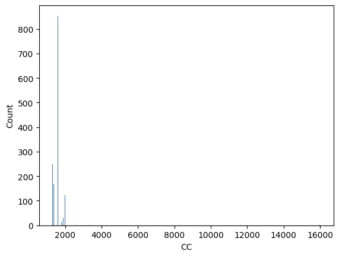

```python
sns.histplot(carPrice_df["CC"])
```

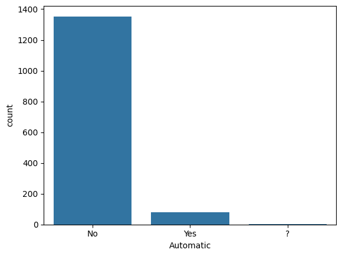

```python
sns.countplot(data=carPrice_df, x="Automatic")
```

Ignore the model column for report as it provides nothing of substance

CC - need to remove car with 16000 CC

Automatic - remove cars with "?"

Guarantee_Period - change 3 year to 36 months

Cylinders - replace -1 with pd.na

Quarterly_Tax - drop all 0.0

START OF CLEANING

```python
carPrice_df.loc[carPrice_df["Quarterly_Tax"] == 0.0]
```

|  | Id | Model | Price | Age_08_04 | KM | Fuel_Type | HP | Color | Automatic | CC | ... | Power_Steering | Radio | Mistlamps | Sport_Model | Backseat_Divider | Metallic_Rim | Radio_cassette | Parking_Assistant | Tow_Bar | Mfg_Date |
| --- | --- | --- | --- | --- | --- | --- | --- | --- | --- | --- | --- | --- | --- | --- | --- | --- | --- | --- | --- | --- | --- |
| 203 | 205 | TOYOTA Corolla 1.9 D HATCHB SOL 2/3-Doors | 10450 | 35 | 91456 | Diesel | 69 | Red (Metallic) | No | 1900 | ... | Yes | No | Yes | No | Yes | No | No | No | No | 10/1/01 |
| 271 | 273 | TOYOTA Corolla 1.6 16V VVT I WAGON TERRA Stati... | 12950 | 38 | 48197 | Petrol | 110 | Black (Metallic) | No | 1600 | ... | Yes | No | No | No | Yes | No | No | No | No | 7/1/01 |
| 277 | 279 | TOYOTA Corolla 1.6 16V VVT I HATCHB TERRA 2/3-... | 11495 | 39 | 46694 | Petrol | 110 | Red | No | 1600 | ... | Yes | No | No | No | Yes | Yes | No | No | No | 6/1/01 |
| 335 | 337 | TOYOTA Corolla 1.6 16V VVT I HATCHB TERRA 2/3-... | 12500 | 35 | 32000 | Petrol | 110 | Black | No | 1600 | ... | Yes | No | No | No | Yes | No | No | No | No | 10/1/01 |

4 rows × 37 columns

dropping car with 16000 CC engine dropping all cars with ? automatic dropping all cars with 0.0 quarterly tax

```python
carPrice_df = carPrice_df.drop({80, 171, 244, 301, 203, 271, 277, 335})
```

[output not shown]

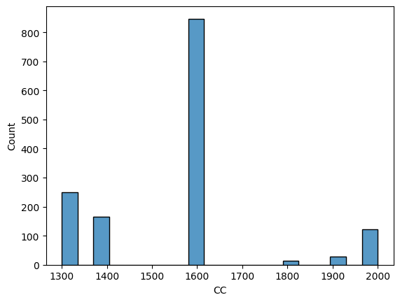

```python
sns.histplot(carPrice_df["CC"])
```

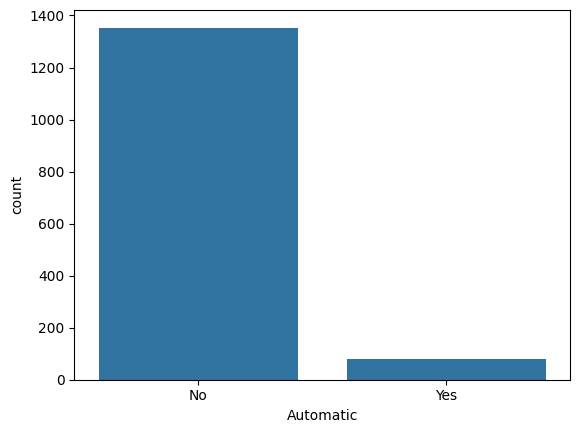

```python
sns.countplot(data=carPrice_df, x="Automatic")
```

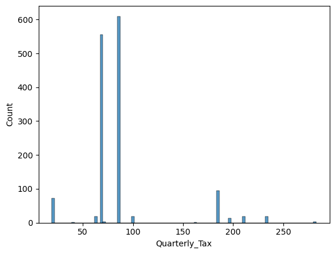

```python
sns.histplot(carPrice_df["Quarterly_Tax"])
```

```python
carPrice_df.loc[carPrice_df['Cylinders'] == -1]
```

|  | Id | Model | Price | Age_08_04 | KM | Fuel_Type | HP | Color | Automatic | CC | ... | Power_Steering | Radio | Mistlamps | Sport_Model | Backseat_Divider | Metallic_Rim | Radio_cassette | Parking_Assistant | Tow_Bar | Mfg_Date |
| --- | --- | --- | --- | --- | --- | --- | --- | --- | --- | --- | --- | --- | --- | --- | --- | --- | --- | --- | --- | --- | --- |
| 0 | 1 | TOYOTA Corolla 2.0 D4D HATCHB TERRA 2/3-Doors | 13500 | 23 | 46986 | Diesel | 90 | Blue (Metallic) | No | 2000 | ... | Yes | No | No | No | Yes | No | No | No | No | 10/1/02 |
| 4 | 5 | TOYOTA Corolla 2.0 D4D HATCHB SOL 2/3-Doors | 13750 | 30 | 38500 | Diesel | 90 | Black | No | 2000 | ... | Yes | No | Yes | No | Yes | No | No | No | No | 3/1/02 |
| 22 | 23 | TOYOTA Corolla 1.6 16V VVT I 3DR SOL 2/3-Doors | 15950 | 28 | 56349 | Petrol | 110 | Black (Metallic) | No | 1600 | ... | Yes | No | Yes | Yes | Yes | Yes | No | No | Yes | 5/1/02 |
| 26 | 27 | TOYOTA Corolla 1.6 16V VVT I 3DR SOL 2/3-Doors | 17495 | 27 | 34545 | Petrol | 110 | Blue (Metallic) | No | 1600 | ... | Yes | No | Yes | No | Yes | Yes | No | No | No | 6/1/02 |
| 31 | 32 | TOYOTA Corolla 1.4 16V VVT I 3DR TERRA COMFORT... | 15750 | 22 | 35199 | Petrol | 97 | Blue (Metallic) | No | 1400 | ... | Yes | No | No | Yes | Yes | Yes | No | No | Yes | 11/1/02 |
| ... | ... | ... | ... | ... | ... | ... | ... | ... | ... | ... | ... | ... | ... | ... | ... | ... | ... | ... | ... | ... | ... |
| 1375 | 1382 | TOYOTA Corolla 1.3 16V SEDAN LINEA TERRA 4/5-D... | 7750 | 80 | 57000 | Petrol | 86 | Blue | No | 1300 | ... | Yes | No | No | No | No | No | No | No | No | 1/1/98 |
| 1406 | 1413 | TOYOTA Corolla 1.6 16V HATCHB LINEA TERRA 2/3-... | 8950 | 70 | 44850 | Petrol | 110 | Blue (Metallic) | No | 1600 | ... | Yes | No | No | Yes | Yes | No | No | No | No | 11/1/98 |
| 1422 | 1429 | TOYOTA Corolla 1.6 16V HATCHB LINEA TERRA 2/3-... | 7600 | 78 | 36000 | Petrol | 110 | Blue (Metallic) | No | 1600 | ... | Yes | No | No | No | Yes | Yes | No | No | No | 3/1/98 |
| 1426 | 1433 | TOYOTA Corolla 1.6 Lin.Terra Aut. 2/3-Doors | 9950 | 78 | 30964 | Petrol | 110 | Silver | Yes | 1600 | ... | Yes | No | No | No | No | No | No | No | Yes | 3/1/98 |
| 1433 | 1440 | TOYOTA Corolla 1.3 16V HATCHB LINEA TERRA 2/3-... | 8500 | 71 | 17016 | Petrol | 86 | Blue | No | 1300 | ... | Yes | No | No | No | Yes | No | No | No | No | 10/1/98 |

66 rows × 37 columns

replacing all -1 cylinders with pd.NA replacing all 3 year guarantee periods with 36 months

```python
carPrice_df = carPrice_df.replace({"Cylinders": -1}, pd.NA)
carPrice_df = carPrice_df.replace({"Guarantee_Period": 3}, 36)
```

```python
carPrice_df.describe()
```

|  | Id | Price | Age_08_04 | KM | HP | CC | Doors | Gears | Quarterly_Tax | Weight | Guarantee_Period |
| --- | --- | --- | --- | --- | --- | --- | --- | --- | --- | --- | --- |
| count | 1428.000000 | 1428.000000 | 1428.000000 | 1428.000000 | 1428.000000 | 1428.000000 | 1428.000000 | 1428.000000 | 1428.000000 | 1428.000000 | 1428.000000 |
| mean | 724.268908 | 10661.277311 | 56.082633 | 68674.696779 | 101.483193 | 1566.432073 | 4.033613 | 5.026611 | 87.087535 | 1072.378852 | 33.084734 |
| std | 416.016249 | 3606.998601 | 18.548073 | 37523.730773 | 14.986530 | 187.484257 | 0.952401 | 0.189028 | 41.152340 | 52.661086 | 8.405322 |
| min | 1.000000 | 1625.000000 | 1.000000 | 1.000000 | 69.000000 | 1300.000000 | 2.000000 | 3.000000 | 19.000000 | 1000.000000 | 6.000000 |
| 25% | 367.750000 | 8450.000000 | 44.000000 | 43000.000000 | 89.000000 | 1400.000000 | 3.000000 | 5.000000 | 69.000000 | 1040.000000 | 36.000000 |
| 50% | 725.500000 | 9897.500000 | 61.000000 | 63567.000000 | 110.000000 | 1600.000000 | 4.000000 | 5.000000 | 85.000000 | 1070.000000 | 36.000000 |
| 75% | 1083.250000 | 11900.000000 | 70.000000 | 87130.750000 | 110.000000 | 1600.000000 | 5.000000 | 5.000000 | 85.000000 | 1085.000000 | 36.000000 |
| max | 1442.000000 | 32500.000000 | 80.000000 | 243000.000000 | 192.000000 | 2000.000000 | 5.000000 | 6.000000 | 283.000000 | 1615.000000 | 36.000000 |

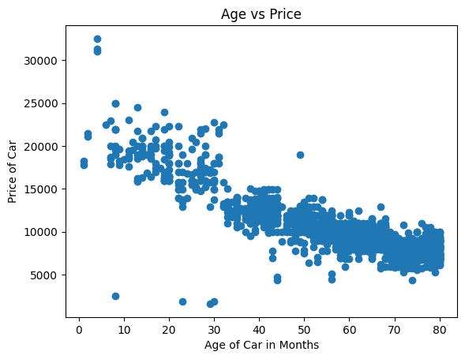

```python
fig, ax = plt.subplots()

ax.scatter(carPrice_df["Age_08_04"], carPrice_df["Price"])
ax.set_xlabel("Age of Car in Months")
ax.set_ylabel("Price of Car")
ax.set_title("Age vs Price")

plt.rcParams['savefig.dpi'] = 300
plt.savefig('priceAgeScatter.png')
plt.show()
```

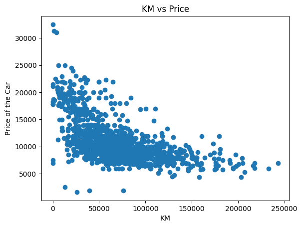

```python
fig, ax = plt.subplots()

ax.scatter(carPrice_df["KM"], carPrice_df["Price"])
ax.set_xlabel("KM")
ax.set_ylabel("Price of the Car")
ax.set_title("KM vs Price")

plt.rcParams['savefig.dpi'] = 300
plt.savefig('priceKMScatter.png')
plt.show()
```

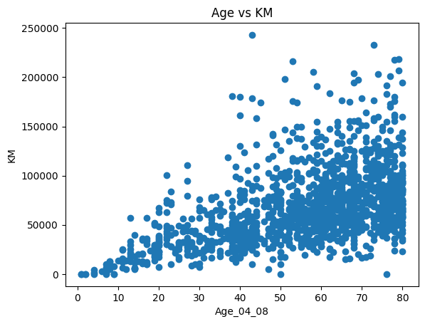

```python
fig, ax = plt.subplots()

ax.scatter(carPrice_df["Age_08_04"], carPrice_df["KM"])
ax.set_xlabel("Age_04_08")
ax.set_ylabel("KM")
ax.set_title("Age vs KM")

plt.rcParams['savefig.dpi'] = 300
plt.savefig('ageKMScatter.png')
plt.show()
```

```python
import pyarrow
carPrice_df.to_feather("cleanCarPrice_df.feather")
```